# Behavioural Data Analysis: Instance Complexity (ICexpost)

J. Pablo Franco, Nitin Yadav, Peter Bossaerts, Carsten Murawski

17 July, 2020

This document contains code used to do the behavioural data analysis related to **Instance Complexity**.

**Important note on terminology:**

1. What we refer to as Instance Complexity (IC) in the main manuscript is sometimes referred to as `ICexpost` in this document.
2. What we refer to in the main manuscript as Typical-case Complexity (TCC) is referred to here in relation to its proximity to the phase transition (`phaseT`):
   - `In the phase transition` refers to high TCC and `Out of the phase transition` refers to low TCC.

```r
#Folder Setup
if(dir.exists("/Volumes/GoogleDrive/My Drive/")){
  folder_drive = "/Volumes/GoogleDrive/My Drive/"
} else {
  folder_drive = "~/Google Drive/"
}

#Import
folder_project = paste0(folder_drive,
                "Melbourne/UNIMELB/Research/Complexity Project/KS-IC")

folder_code =  paste0(folder_project,"/Code/Behavioural-Analysis/PNAS")

folder_data =  paste0(folder_project,"/Data/Behav/Work Data/Exp/Processed/")

#Decision Data
fileDataDec=paste0(folder_data,"KSDec_clean.csv")

#Click-Optimisation Variant Data
fileDataClicks=paste0(folder_data,"KSOpt_clicks_clean.csv")

#write_csv(dataDecProp, path = paste0(folder_data,"data_input_ks_ic.csv"))
#dataInput = dataDecProp
setwd(folder_code)
knitr::opts_knit$set(root.dir = folder_code)
```

```r
# Functions

source(paste0(folder_code, "/DescriptiveFunctions.R"))

#' Create the formatted table for statistical model export
#'
#' @param model model to be exported
#' @param title Caption shown aththe top of the table
#' @param outputType "html" or "latex"
#' @param outputName The name of the output file
#'
#' @return The text of the table
#' @export table Exports tables if outputType==Latex
modelTableStyle = function(model,title,outputType,outputName){
  print(outputName)
  # Stores the model in the list with all the models
  allModels_ICexpost[[outputName]]<<-model
  if (outputType=="html"){
      table = stargazer(model, type=outputType, report=('vc*sp'),#(('vc*p'))
                        column.labels=c("Random Intercept"), dep.var.caption = title,
                        dep.var.labels.include = TRUE,model.names=FALSE,
                        align=TRUE, column.sep.width = "5000pt")
  } else if (outputType=="latex"){
          table = stargazer(model, type=outputType, report=('vc*sp'),
                            column.labels=c("Random Intercept"), dep.var.caption = title,
                            dep.var.labels.include = TRUE,model.names=FALSE, align=TRUE,
                            column.sep.width = "0pt",
                            out = paste0("Output/Tables/",outputName,".tex"),table.placement="H")
  }
  #return(table)
}

plotExport2 = function(plot,outputName, height=3, width=4, units="in", type = "pdf"){
  path = "/Output/Figures/"
  ggsave(paste0(folder_code,path,outputName,".",type),
         plo,height=height,width=width,units = units)
}
```

# Decision Variant

```r
# Data Import
dataInput = read_csv(fileDataDec)
  #read_csv(paste0(folder_data,"data_input_ks_ic.csv"),
                     # col_types = cols(w = col_character(),
                     #                  v = col_character()))

#Stores a list of all the regressions that are run
allModels_ICexpost=vector("list", length=0)
```

```r
#Data preparation

# Summarise the data to plot
mean_accuracy = dataInput %>%
  group_by(instanceNumber,sol,n_dist_opt_p,phaseT,
           propagations,ICexpost,nSolutions) %>%
  summarise(accuracy = mean(correct))
# Generate mean accuracies without outliers
outliers = boxplot.stats(mean_accuracy$accuracy)$out
mean_accuracy_clean = mean_accuracy %>% filter(!(accuracy %in% outliers))

mean_accuracy$outlier = (mean_accuracy$accuracy %in% outliers)
```

### Number of solution verifiers and $IC_{expost}$

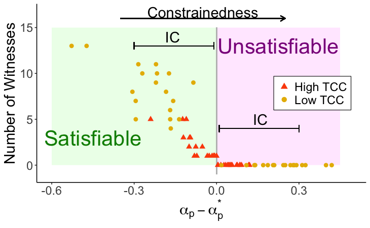

```r
dat2 =mean_accuracy

dat2$phaseT =ifelse(dat2$phaseT==1,"High TCC","Low TCC")
dat2$phaseT = as.factor(dat2$phaseT)

  # scale_shape_manual(values = c(16, 17)) +
  # scale_color_manual(values = c("#E7B800", "#FC4E07"))
size_big = 20
size_small = 16
size_ss = 10
size_xs = 7

#x_title =expression(frac(alpha[p]-alpha[p]^"*",paste(Sigma,v[i])))
x_title =expression(alpha[p]-alpha[p]^"*")

plo= ggplot(dat2, aes(x=n_dist_opt_p, y=nSolutions))+
  annotate("rect",xmin=-0.6,xmax=0,ymin=0,ymax=15, alpha=0.1, fill="green")+
  annotate("rect",xmin=0.45,xmax=0,ymin=0,ymax=15, alpha=0.1, fill="magenta")+
  annotate("text",x=-0.45,y=3, color="green4", label="Satisfiable",size = size_ss)+
  annotate("text",x=0.225,y=13, color="magenta4", label="Unsatisfiable", size = size_ss)+
  geom_segment(aes(x=0,xend=0,y=-1,yend=15), color= "gray")+
  geom_point(aes(color=phaseT,shape=phaseT), size=2.5)+
  xlab(x_title)+#expression(V[opt]-V[target]))+
  ylab("Number of Witnesses")+
  scale_shape_manual(name="",values = c(17,16)) +
  scale_color_manual(name="",values = c( "#FC4E07","#E7B800"))+
  annotate("text",x=-0.16,y=14,label=expression(paste("IC")),size=size_xs)+
  geom_segment(aes(x=-0.3,xend=-0.01,y=13,yend=13), arrow = arrow(length = unit(0.02, "npc"), ends ="both", angle =90))+
  annotate("text",x=0.16,y=5,label=expression(paste("IC")),size=size_xs)+
  geom_segment(aes(x=0.3,xend=0.01,y=4,yend=4), arrow = arrow(length = unit(0.02, "npc"), ends ="both", angle =90))+
  theme_classic()+
  theme(axis.title = element_text(size= size_big),
       axis.text=element_text(size=size_small),
       legend.justification=c(0.94,0.5),
       legend.position=c(0.94,0.5),
       legend.text = element_text(size=size_small),
       #legend.background = element_rect(colour = "black"),
       legend.background = element_blank(),
       legend.box.background = element_rect(colour = "black", fill="white"),
       legend.title = element_blank(),
      legend.spacing.y = unit(0, "mm"))+
  guides(shape = guide_legend(override.aes = list(size = 3)))+
  xlim(NA, 0.49)+
  geom_segment(aes(x=-0.35,xend=0.25,y=16,yend=16), arrow = arrow(length = unit(0.03, "npc"), ends ="last"))+
    annotate("text",x=-0.05,y=16.7,label="Constrainedness",size=size_xs)


outputName="ICexpost_nSol"
plotExport2(plo,outputName, height=5, width=9, units ="in")
plo
```

```r
NA
NA
```